# 9 Visualizing data distributions

[Book](http://rafalab.dfci.harvard.edu/dsbook/r-basics.html)

R commands in this chapter

|`cur_column`| `cur_group`| `cur_group_id`| `cur_group_rows`| `dnorm`| `geom_bar`| `geom_boxplot`| `geom_density`| `geom_histogram`| `geom_qq`| `geom_raster`| `geom_tile`| `I`| `n`| `pnorm`| `prop.table`| `qnorm`| `qplot`| `quantile`| `rnorm`| `scale_fill_gradient`| `stat_ecdf`|

You may have noticed that numerical data is often summarized with the average value. For example, the quality of a high school is sometimes summarized with one number: the average score on a standardized test. Occasionally, a second number is reported: the standard deviation. For example, you might read a report stating that scores were 680 plus or minus 50 (the standard deviation). The report has summarized an entire vector of scores with just two numbers. Is this appropriate? Is there any important piece of information that we are missing by only looking at this summary rather than the entire list?

Our first data visualization building block is learning to summarize lists of factors or numeric vectors. More often than not, the best way to share or explore this summary is through data visualization. The most basic statistical summary of a list of objects or numbers is its distribution. Once a data has been summarized as a distribution, there are several data visualization techniques to effectively relay this information. For this reason, it is important to have a deep understand the concept of a distribution.

In this chapter, we first discuss properties of a variety of distributions and how to visualize distributions using a motivating example of student heights. We then discuss the **ggplot2** geometries for these visualizations in Section 9.8.

# 9.1 Variable types

The two main variables types are **categorical** and **numeric**. Each can be divided into two other groups: categorical can be ordinal or not, whereas numerical variables can be discrete or continuous. When each entry in a dataset comes from one of a small number of groups, we refer to the data as categorical data. Two simple examples are sex (male or female) and US regions (Northeast, South, North Central, West). Some categorical data can be ordered even if they are not numbers per se, such as spiciness (mild, medium, hot). In statistics textbooks, ordered categorical data are referred to as ordinal data. Examples of numerical data are population sizes, murder rates, and heights. Some numerical data can be treated as ordered categorical. We can further divide numerical data into continuous and discrete. Continuous variables are those that can take any value, such as heights, if measured with enough precision. For example, a pair of twins may be 68.12 and 68.11 inches, respectively. Counts, such as population sizes, are discrete because they have to be round numbers.

Keep in mind that discrete numeric data can be considered ordinal. Although this is technically true, we usually reserve the term ordinal data for variables belonging to a small number of different groups, with each group having many members. In contrast, when we have many groups with few cases in each group, we typically refer to them as discrete numerical variables. So, for example, the number of packs of cigarettes a person smokes a day, rounded to the closest pack, would be considered ordinal, while the actual number of cigarettes would be considered a numerical variable. But, indeed, there are examples that can be considered both numerical and ordinal when it comes to visualizing data.

Here we focus on numeric variables because visualizing this data type is substantially more complex. However, we start by describing data visualization and summarization approaches for categorical data.

# 9.2 Case study: describing student heights

Pretend that we have to describe the heights of our classmates to ET, an extraterrestrial that has never seen humans. As a first step, we need to collect data. To do this, we ask students to report their heights in inches. We ask them to provide sex information because we know there are two different distributions by sex. We collect the data and save it in the `heights` data frame:

```r
library(tidyverse)
library(dslabs)
data(heights)
```

One way to convey the heights to ET is to simply send him this list of 1050 heights. But there are much more effective ways to convey this information, and understanding the concept of a distribution will be key. To simplify the explanation, we first focus on male heights. We examine the female height data in Section 9.6.

# 9.3 Distributions

The most basic statistical summary of a list of objects or numbers is its distribution. The simplest way to think of a distribution is as a compact description of a list with many entries. This concept should not be new for readers of this book. For example, with categorical data, the distribution simply describes the proportion of each unique category. The sex represented in the heights dataset is:

```r
prop.table(table(heights$sex))
```

```
##
##    Female      Male
## 0.2266667 0.7733333
```

**`prop.table`** Returns conditional proportions given margins, i.e. entries of x, divided by the appropriate marginal sums.

This two-category frequency table is the simplest form of a distribution. We don’t really need to visualize it since one number describes everything we need to know: 23% are females and the rest are males. When there are more categories, then a simple barplot describes the distribution. Here is an example with US state regions:

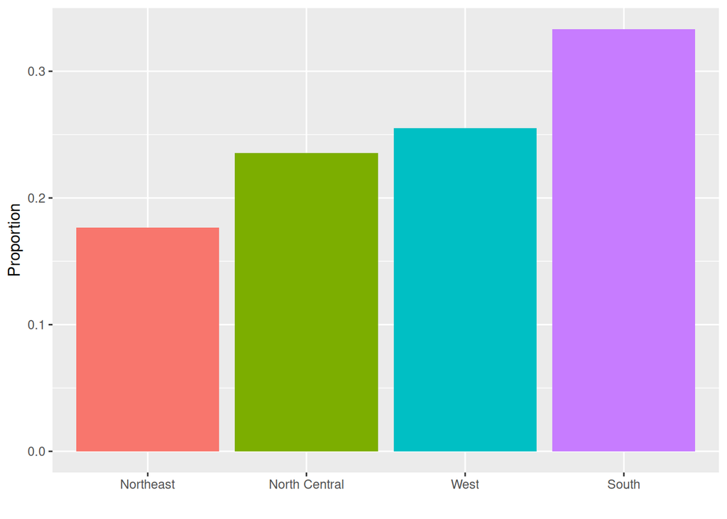

```r
murders |>
  group_by(region) |>
  summarise(n = n()) |>
  mutate(Proportion = n/sum(n),
         region = reorder(region, Proportion)) |>
  ggplot(aes(x = region,
             y = Proportion,
             fill = region)) +
  geom_bar(stat = "identity", show.legend = FALSE) +
  xlab("")
```

**Information about the “current” group or variable**

> These functions return information about the “current” group or “current” variable, so only work inside specific contexts like `summarise()` and `mutate()`.
> - `n()` gives the current group size.
> - `cur_group()` gives the group keys, a tibble with one row and one column for each grouping variable.
> - `cur_group_id()` gives a unique numeric identifier for the current group.
> - `cur_group_rows()` gives the row indices for the current group.
> - `cur_column()` gives the name of the current column (in across() only).

> See `group_data()` for equivalent functions that return values for all groups.

This particular plot simply shows us four numbers, one for each category. We usually use barplots to display a few numbers. Although this particular plot does not provide much more insight than a frequency table itself, it is a first example of how we convert a vector into a plot that succinctly summarizes all the information in the vector. When the data is numerical, the task of displaying distributions is more challenging.

## 9.3.1 Histograms

Numerical data that are not categorical also have distributions. However, in general, when data is not categorical, reporting the frequency of each entry, as we did for categorical data, is not an effective summary since most entries are unique. or example, in our case study, while several students reported a height of 68 inches, only one student reported a height of `68.503937007874` inches and only one student reported a height `68.8976377952756` inches. We assume that they converted from 174 and 175 centimeters, respectively.

Statistics textbooks teach us that a more useful way to define a distribution for numeric data is to define a function that reports the proportion of the data below $a$ for all possible values of $a$. This function is called the **emipirical cumulative distribution function (eCDF)**, it can be plotted, and it provides a full description of the distribution of our data. Here is the eCDF for male student heights:

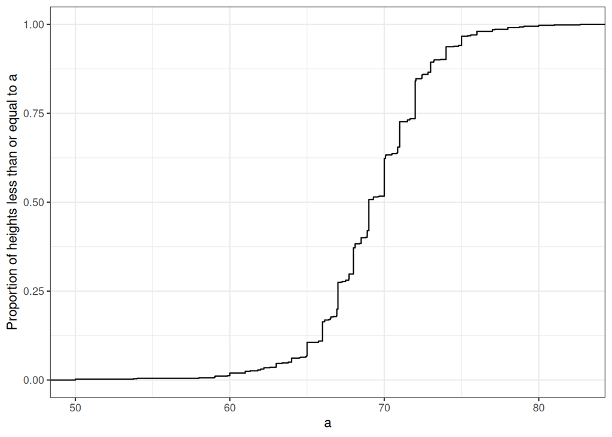

```r
ds_theme_set()
heights |>
  filter(sex == "Male") |>
  ggplot(aes(height)) +
  stat_ecdf() +
  ylab("Proportion of heights less than or equal to a") +
  xlab("a")
```

**Compute empircal cumulative distribution**

> The empirical cumulative distribution function (ECDF) provides an alternative visualisation of distribution. Compared to other visualisations that rely on density (like geom_histogram()), the ECDF doesn’t require any tuning parameters and handles both continuous and categorical variables. The downside is that it requires more training to accurately interpret, and the underlying visual tasks are somewhat more challenging.

However, summarizing data by plotting the eCDF is actually not very popular in practice. The main reason is that it does not easily convey characteristics of interest such as: at what value is the distribution centered? Is the distribution symmetric? What ranges contain 95% of the values?

*Histograms*, are much preferred because they greatly facilitate answering such questions. Histograms sacrifice just a bit of information to produce plots that are much easier to interpret. The simplest way to make a histogram is to divide the span of our data into non-overlapping bins of the same size. Then, for each bin, we count the number of values that fall in that interval. The histogram plots these counts as bars with the base of the bar defined by the intervals. Here is the histogram for the height data splitting the range of values into one inch intervals: $(49.5,50.5],(50.5,51.5],(51.5,52.5],(52.5,53.5],\dots,(82.5,83.5]$

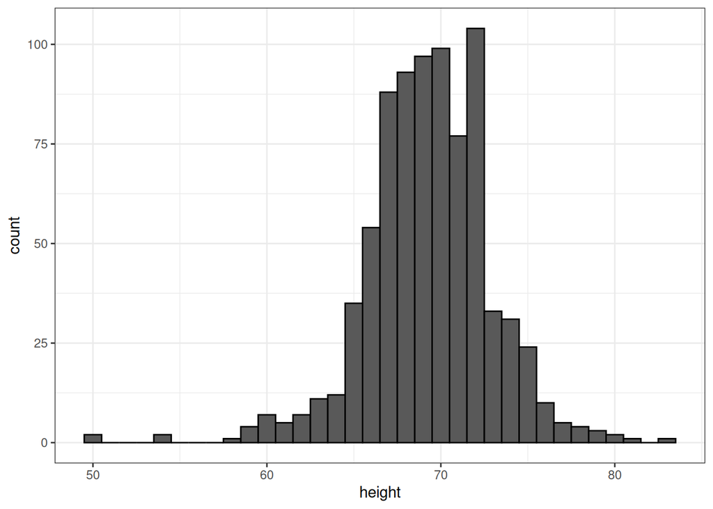

```r
heights |>
  filter(sex == "Male") |>
  ggplot(aes(height)) +
  geom_histogram(binwidth = 1,
                 color = "black")
```

As you can see in the figure above, a histogram is similar to a barplot, but it differs in that the x-axis is numerical, not categorical.

If we send this plot to ET, he will immediately learn some important properties about our data. First, the range of the data is from 50 to 84 with the majority (more than 95%) between 63 and 75 inches. Second, the heights are close to symmetric around 69 inches. Also, by adding up counts, ET could obtain a very good approximation of the proportion of the data in any interval. Therefore, the histogram above is not only easy to interpret, but also provides almost all the information contained in the raw list of 812 heights with about 30 bin counts.

We discuss how to code histograms in Section 9.8.

## 9.3.2 Smoothed density

*Smooth density* plots relay the same information as a histogram but are aesthetically more appealing. Here is what a smooth density plot looks like for our heights data:

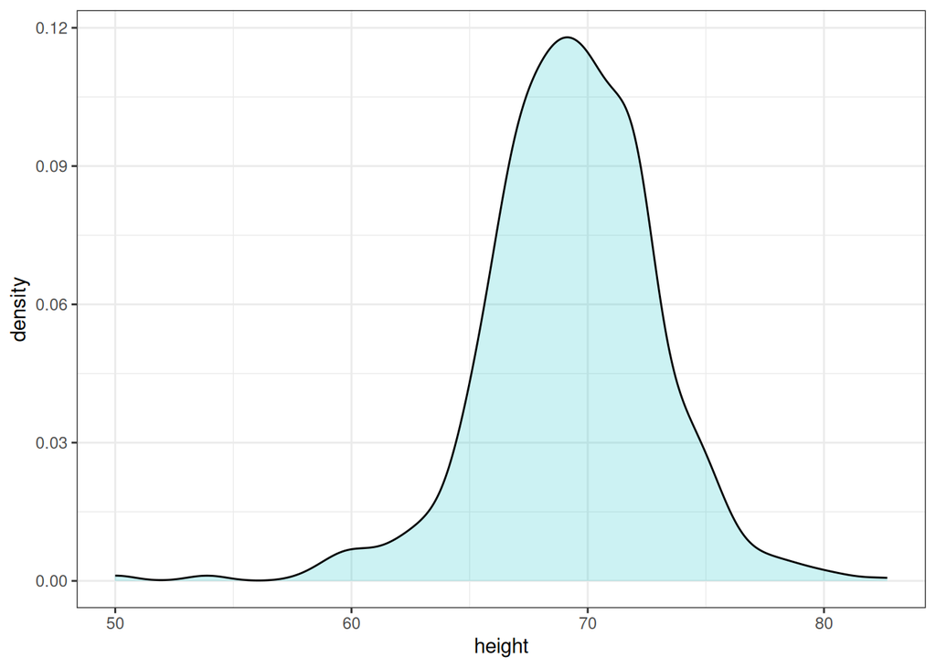

```r
heights |>
  filter(sex=="Male") |>
  ggplot(aes(height)) +
  geom_density(alpha = .2,
               fill= "#00BFC4",
               color = 0)  +
  geom_line(stat='density')
```

In this plot, we no longer have sharp edges at the interval boundaries and many of the local peaks have been removed. Also, the scale of the y-axis changed from counts to density. To fully understand smooth densities, we have to understand *estimates*, a topic we don’t cover until later. Here we simply describe them as making the histograms prettier by drawing a curve that goes through the top of the histogream bars and then removing the bars. The values shown y-axis are chosen so that the area under the curve at up to 1. This implies that for any interval, the area under the curve for that interval gives us an approximation of how what proportion of the data is in the interval.

An advantage of smooth densities over histograms for visualization purposes is that densities make it easier to compare two distributions. This is in large part because the jagged edges of the histogram add clutter. Here is an example comparing male and female heights:

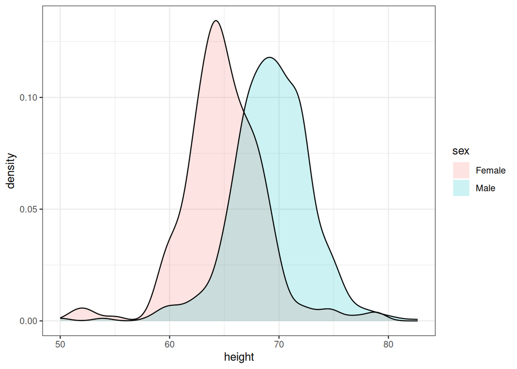

```r
heights |>
  ggplot(aes(height,
             fill = sex)) +
  geom_density(alpha = 0.2,
               color = 0) +
  geom_line(stat = "density")
```

With the right argument, **ggplot** automatically shades the intersecting region with a different color. We will show examples of **ggplot2** code for densities in Section 10 as well as Section 9.8.

## 9.3.3 The normal distribution

The normal distribution, also known as the bell curve and as the Gaussian distribution. Here is what the normal distribution looks like:

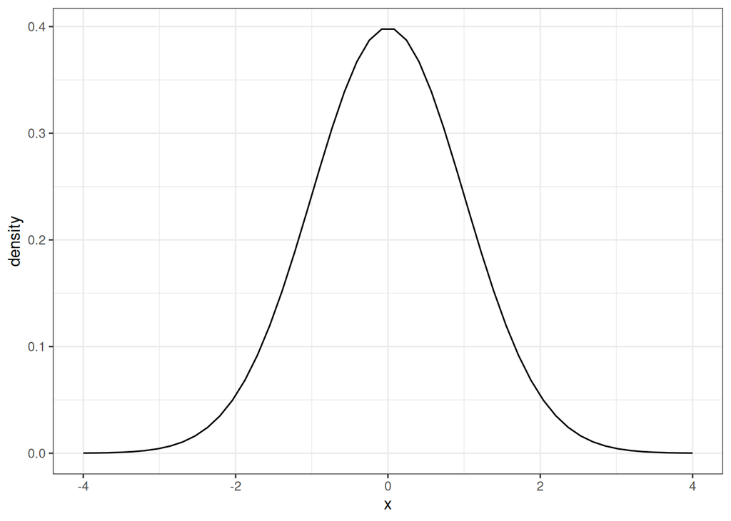

```r
mu <- 0
s <- 1
norm_dist <-
  data.frame(x = seq(-4, 4, len=50)*s+mu) |>
  mutate(density = dnorm(x, mu, s))
norm_dist |>
  ggplot(aes(x, density)) +
  geom_line()
```

**Generate a normal distribution**

> - Probability density function: **`dnorm(x)`** where `x` is a vector of quantiles
> - Cumulateive density function: **`pnorm(q)`** where `q` is a vector of quantiles
> - Quantile function: **`qnorm(p)`** where `p` is a vector of probabilities
> - Random generation: **`rnorm(n)`** where `n` is number of observations

The normal distribution is one of the most famous mathematical concepts in history. A reason for this is that the distribution of many datasets can be approximated with normal distributions. These include including gambling winnings, heights, weights, blood pressure, standardized test scores, and experimental measurement errors. Statistical textbooks offer explanations for why this is the case. But how can the same distribution approximate datasets with completely different ranges for values, for example heights and weights? A second important characteristic of the normal distribution is that it can be adapted to different datasets by just adjusting two numbers, referred to as the average or mean and the standard deviation (SD). The normal distribution is symmetric, centered at what we refer to as the average, and most values (about 95%) are within 2 SDs from the average. The plot above shows a normal distribution with average 0 and SD 1, often referred to as a **standard normal**. Note that the fact that because only two numbers are needed to adapt the normal distribution to a dataset, implies that if our data distribution is approximated by a normal distribution, all the information needed to describe the distribution can be encoded in just two numbers. We now define these values for an arbitrary list of numbers.

> **Additional material from the on-line course**

> **Key points**
> - The normal distribution:
>   - Is centered around one value, the mean
>   - Is symmetric around the mean
>   - Is defined completely by its mean ($\mu$) and standard deviation ($\sigma$)
>   - Always has the same proportion of observations within a given distance of the mean (for example, 95% within 2$\sigma$ )
> - The standard deviation is the average distance between a value and the mean value.
> - Calculate the mean using the `mean()` function.
> - Calculate the standard deviation using the `sd()` function or manually.
> - Standard units describe how many standard deviations a value is away from the mean. The z-score, or number of standard deviations an observation is away from the mean $\mu$:

> $$Z=\frac{x-\mu}{\sigma}$$
> - Compute standard units with the `scale()` function. - **Important**: to calculate the proportion of values that meet a certain condition, use the mean() function on a logical vector. Because TRUE is converted to 1 and FALSE is converted to 0, taking the mean of this vector yields the proportion of TRUE. Equation for the normal distribution The normal distribution is mathematically defined by the following formula for any mean and standard deviation :

> $$\mbox{Pr}(a < x < b) = \int_a^b \frac{1}{\sqrt{2\pi}\sigma} e^{-\frac{1}{2}\left( \frac{x-\mu}{\sigma} \right)^2} \, dx$$

> NOTE: The average and standard deviation obtained by using the code below are 69.31 and 3.61, respectively. These values appear in the video, but differ slightly from the audio.

> ```r
> index <- heights$sex == "Male"
> x <- heights$height[index]
>
> # calculate standard units
>
> z <- scale(x)
>
> # calculate proportion of values within 2 SD of mean
> mean(abs(z) < 2)
> ```

> ```
> ## [1] 0.9495074
> ```

> **The 68-95-99.7 Rule**

> The normal distribution is associated with the 68-95-99.7 rule. This rule describes the probability of observing events within a certain number of standard deviations of the mean.

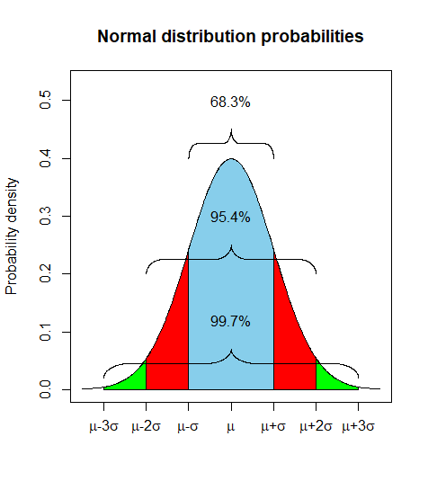

> The probability distribution function for the normal distribution is defined such that:
> - About 68% of observations will be within one standard deviation of the mean ($\mu\pm\sigma$). In standard units, this is equivalent to a z-score of $|z|\le1$.
> - About 95% of observations will be within two standard deviations of the mean ($\mu\pm2\sigma$). In standard units, this is equivalent to a z-score of $|z|\le2$.
> - About 99.7% of observations will be within three standard deviations of the mean ($\mu\pm3\sigma$). In standard units, this is equivalent to a z-score of $|z|\le3$.

> **`pnorm`**
> - The normal distribution has a mathematically defined CDF which can be computed in R with the function `pnorm()`.
> - `pnorm(a, avg, s)` gives the value of the cumulative distribution function for the normal distribution defined by average avg and standard deviation s.
> - We say that a random quantity is normally distributed with average avg and standard deviation `s` if the approximation `pnorm(a, avg, s)` holds for all values of `a`.
> - If we are willing to use the normal approximation for height, we can estimate the distribution simply from the mean and standard deviation of our values.
> - If we treat the height data as discrete rather than categorical, we see that the data are not very useful because integer values are more common than expected due to rounding. This is called **discretization**.
> - With rounded data, the normal approximation is particularly useful when computing probabilities of intervals of length 1 that include exactly one integer.

> **Using pnorm to calculate probabilities**

> ```r
> pnorm(70.5, mean(x), sd(x))
> ```

> ```
> ## [1] 0.628631
> ```

> **plot distribution of exact heights in data**

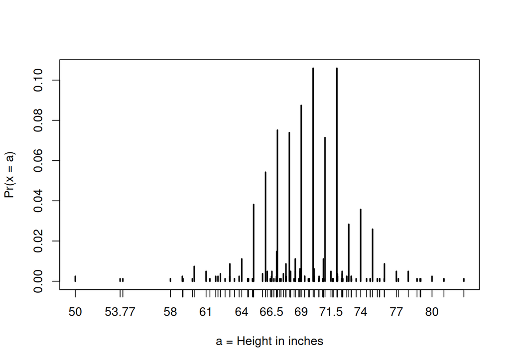

> ```r
> plot(prop.table(table(x)), xlab = "a = Height in inches", ylab = "Pr(x = a)")
> ```

> **probabilities in actual data over length 1 ranges containing an integer**

> ```r
> mean(x <= 68.5) - mean(x <= 67.5)
> ```

> ```
> ## [1] 0.114532
> ```

> ```r
> mean(x <= 69.5) - mean(x <= 68.5)
> ```

> ```
> ## [1] 0.1194581
> ```

> ```r
> mean(x <= 70.5) - mean(x <= 69.5)
> ```

> ```
> ## [1] 0.1219212
> ```

> **probabilities in normal approximation match well**

> ```r
> pnorm(68.5, mean(x), sd(x)) - pnorm(67.5, mean(x), sd(x))
> ```

> ```
> ## [1] 0.1031077
> ```

> ```r
> pnorm(69.5, mean(x), sd(x)) - pnorm(68.5, mean(x), sd(x))
> ```

> ```
> ## [1] 0.1097121
> ```

> ```r
> pnorm(70.5, mean(x), sd(x)) - pnorm(69.5, mean(x), sd(x))
> ```

> ```
> ## [1] 0.1081743
> ```

> **probabilities in actual data over other ranges don’t match normal approx as well**

> ```r
> mean(x <= 70.9) - mean(x <= 70.1)
> ```

> ```
> ## [1] 0.02216749
> ```

> ```r
> pnorm(70.9, mean(x), sd(x)) - pnorm(70.1, mean(x), sd(x))
> ```

> ```
> ## [1] 0.08359562
> ```

Once we are convinced that our data, say it is stored in the vector `x`, has a distribution that is approximately normal we can find the specific one that matches our data by matching the average and SD of the data to the average and SD of the normal distribution, respectively. For a list of numbers contained in a vector `x`:

```r
index <- heights$sex == "Male"
x <- heights$height[index]
```

the average is defined as

```r
m <- sum(x) / length(x)
m
```

```
## [1] 69.31475
```

and the SD is defined as

```r
s <- sqrt(sum(x-mu^2) / length(x))
```

The pre-built functions mean and sd can be used here. (Note that, for reasons explained in statistics textbooks, `sd` divides by `length(x)-1` rather than `length(x)`)

```r
m <- mean(x)
s <- sd(x)
c(average = m, sd = s)
```

```
##   average        sd
## 69.314755  3.611024
```

Here is a plot of the smooth density and the normal distribution with mean = 69.3 and SD = 3.6 plotted as a black line with our student height smooth density in blue:

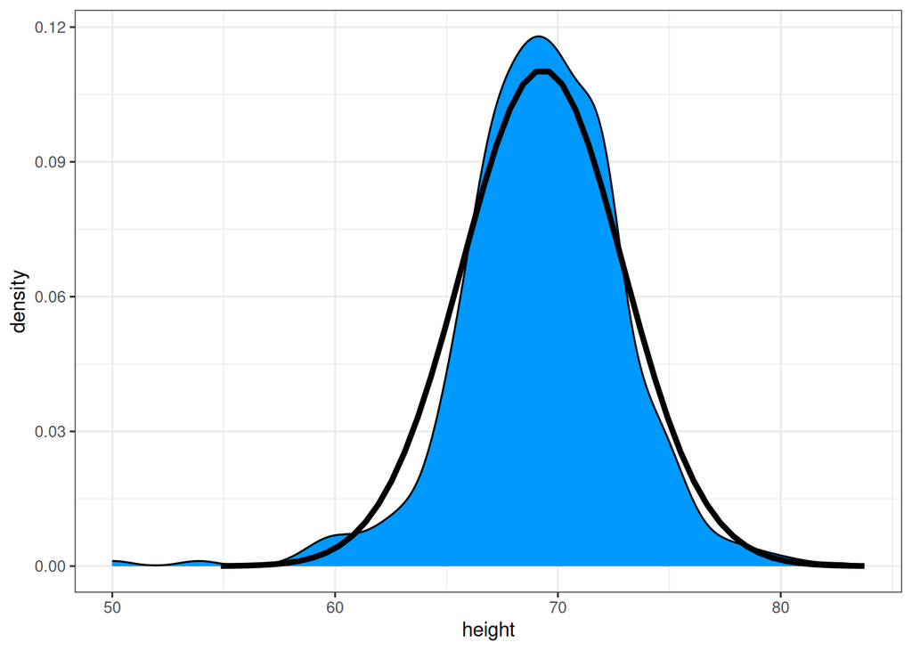

```r
norm_dist <-
  data.frame(x = seq(-4, 4, len = 50)*s + m) |>
  mutate(density = dnorm(x, m, s))
heights |>
  filter(sex == "Male") |>
  ggplot(aes(height)) +
  geom_density(fill = "#0099FF") +
  geom_line(aes(x, density),
            data = norm_dist,
            lwd = 1.5)
```

# 9.4 Boxplots

To understand boxplots we need to define some terms that are commonly used in exploratory data analysis.

The percentiles are the values for which $p=0.01,0.02,\dots,0.99$ of the data are less then or equal to that value, respectively. We call, for example, the case of $p=0.10$ the 10th percentile, which gives us a number for which 10% of the data is below. The most famous percentile is the 50th, also known as the median. Another special case that receives a name are the quartiles, which are obtained when setting $p=0.25,0.50,\text{ and } 0.75$, which are used by the boxplot.

> **Definition of quantiles**

> Quantiles are cutoff points that divide a dataset into intervals with set probabilities. The $q$th quantile is the value at which $q$% of the observations are equal to or less than that value.

> **Using the quantile function**

> Given a dataset data and desired quantile q, you can find the qth quantile of data with:

> ```
> quantile(data, q)
> ```

> **Percentiles**

> Percentiles are the quantiles that divide a dataset into 100 intervals each with 1% probability. You can determine all percentiles of a dataset data like this:

> ```
> p <- seq(0.01, 0.99, 0.01)
> quantile(data, p)
> ```

> **Quartiles**

> Quartiles divide a dataset into 4 parts each with 25% probability. They are equal to the 25th, 50th and 75th percentiles. The 25th percentile is also known as the 1st quartile, the 50th percentile is also known as the median, and the 75th percentile is also known as the 3rd quartile.

> The `summary()` function returns the minimum, quartiles and maximum of a vector.

> ```r
> summary(heights$height)
> ```

> ```
> ##    Min. 1st Qu.  Median    Mean 3rd Qu.    Max.
> ##   50.00   66.00   68.50   68.32   71.00   82.68
> ```

> Find the percentiles of heights$height:

> ```r
> p <- seq(0.01, 0.99, 0.01)
> percentiles <- quantile(heights$height, p)
> ```

> Confirm that the 25th and 75th percentiles match the 1st and 3rd quartiles. Note that quantile() returns a named vector. You can access the 25th and 75th percentiles like this (adapt the code for other percentile values):

> ```r
> percentiles[names(percentiles) == "25%"]
> ```

> ```
> ## 25%
> ##  66
> ```

> ```r
> percentiles[names(percentiles) == "75%"]
> ```

> ```
> ## 75%
> ##  71
> ```

> **`qnorm`**

> The `qnorm()` function gives the theoretical value of a quantile with probability p of observing a value equal to or less than that quantile value given a normal distribution with mean mu and standard deviation sigma:

> ```
> qnorm(p, mu, sigma)
> ```

> By default, mu=0 and sigma=1. Therefore, calling `qnorm()` with no arguments gives quantiles for the standard normal distribution.

> ```
> qnorm(p)
> ```

> Recall that quantiles are defined such that p is the probability of a random observation less than or equal to the quantile.

> **Relation to `pnorm`**

> The `pnorm()` function gives the probability that a value from a standard normal distribution will be less than or equal to a z-score value z. Consider:
> $$\text{pnorm}(-1.96)\approx0.025$$
> The result of pnorm() is the quantile. Note that:
> $$\text{qnorm}(0.025)\approx-1.96$$
> qnorm() and pnorm() are inverse functions:
> $$\text{pnorm}(\text{qnorm}(0.025))=0.025$$
> **Theoretical quantiles**

> You can use `qnorm()` to determine the theoretical quantiles of a dataset: that is, the theoretical value of quantiles assuming that a dataset follows a normal distribution. Run the `qnorm()` function with the desired probabilities p, mean mu and standard deviation sigma.

> Suppose male heights follow a normal distribution with a mean of 69 inches and standard deviation of 3 inches. The theoretical quantiles are:

> ```r
> p <- seq(0.01, 0.99, 0.01)
> theoretical_quantiles <- qnorm(p, 69, 3)
> theoretical_quantiles
> ```

> ```
> ##  [1] 62.02096 62.83875 63.35762 63.74794 64.06544 64.33568 64.57263 64.78479
> ##  [9] 64.97773 65.15535 65.32042 65.47504 65.62083 65.75904 65.89070 66.01663
> ## [17] 66.13750 66.25390 66.36631 66.47514 66.58074 66.68342 66.78346 66.88109
> ## [25] 66.97653 67.06996 67.16156 67.25148 67.33985 67.42680 67.51245 67.59690
> ## [33] 67.68026 67.76261 67.84404 67.92462 68.00444 68.08356 68.16204 68.23996
> ## [41] 68.31737 68.39432 68.47088 68.54709 68.62302 68.69870 68.77419 68.84954
> ## [49] 68.92479 69.00000 69.07521 69.15046 69.22581 69.30130 69.37698 69.45291
> ## [57] 69.52912 69.60568 69.68263 69.76004 69.83796 69.91644 69.99556 70.07538
> ## [65] 70.15596 70.23739 70.31974 70.40310 70.48755 70.57320 70.66015 70.74852
> ## [73] 70.83844 70.93004 71.02347 71.11891 71.21654 71.31658 71.41926 71.52486
> ## [81] 71.63369 71.74610 71.86250 71.98337 72.10930 72.24096 72.37917 72.52496
> ## [89] 72.67958 72.84465 73.02227 73.21521 73.42737 73.66432 73.93456 74.25206
> ## [97] 74.64238 75.16125 75.97904
> ```

> Theoretical quantiles can be compared to sample quantiles determined with the quantile function in order to evaluate whether the sample follows a normal distribution.

To motivate boxplots we will go back to the US murder data. Suppose we want to summarize the murder rate distribution. Using the data visualization technique we have learned, we can quickly see that the normal approximation does not apply here:

```r
data(murders)
murders <-
  murders |>
  mutate(rate = total / population * 10^5)
library(gridExtra)
```

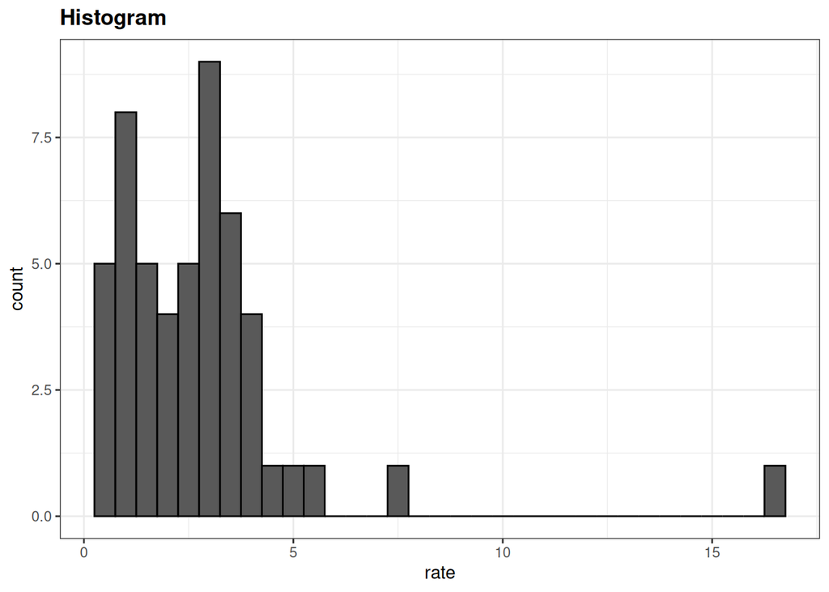

```r
murders |>
  ggplot(aes(x = rate)) +
  geom_histogram(binwidth = 0.5,
                 color = "black") +
  ggtitle("Histogram")
```

In this case, the histogram above or a smooth density plot would serve as a relatively succinct summary.

Now suppose those used to receiving just two numbers as summaries ask us for a more compact numerical summary.

The boxplot provides a five-number summary composed of the range along with the quartiles (the 25th, 50th, and 75th percentiles). The R implementation of boxplots ignore *outliers* when computing the range and instead plot these as independent points. The help file provides a specific definition of outliers. The boxplot shows these numbers as a “box” with “whiskers”

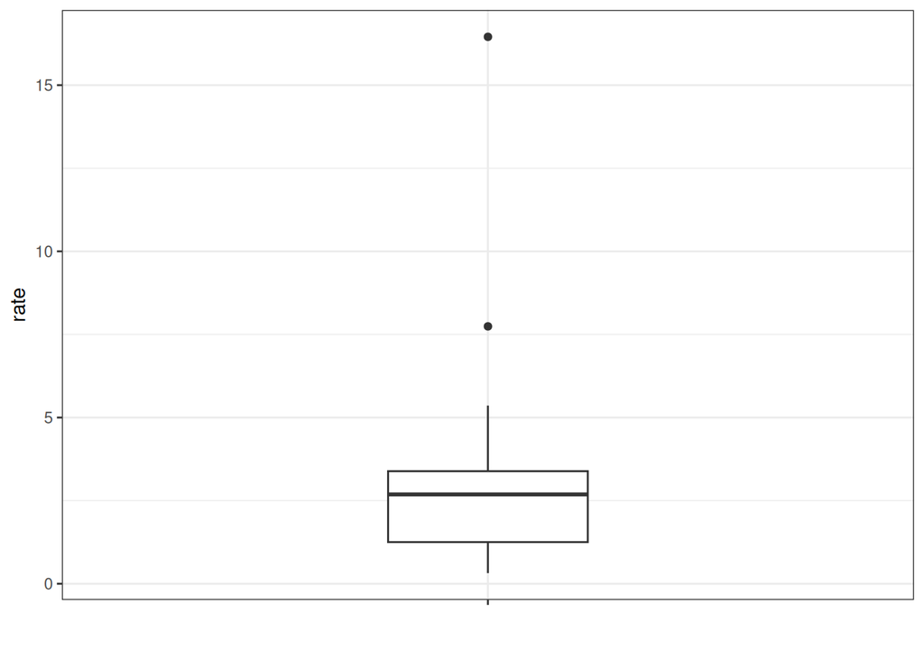

```r
murders |>
  ggplot(aes("", rate)) +
  geom_boxplot() +
  coord_cartesian(xlim = c(0,2)) +
  xlab("")
```

with the box defined by the 25% and 75% percentile and the whiskers showing the range. The distance between these two is called the interquartile range. The two points are outliers according to the R implementation. The median is shown with a horizontal line.

From just this simple plot, we know that the median is about 2.5, that the distribution is not symmetric, and that the range is 0 to 5 for the great majority of states with two exceptions.

We discuss how to make boxplots in Section 9.8.

## QQ-plots

**Key points**

- Quantile-quantile plots, or QQ-plots, are used to check whether distributions are well-approximated by a normal distribution.
- Given a proportion $p$, the quantile $q$ is the value such that the proportion of values in the data below $q$ is $p$.
- In a QQ-plot, the sample quantiles in the observed data are compared to the theoretical quantiles expected from the normal distribution. If the data are well-approximated by the normal distribution, then the points on the QQ-plot will fall near the identity line (sample = theoretical).
- Calculate sample quantiles (observed quantiles) using the `quantile()` function.
- Calculate theoretical quantiles with the `qnorm()` function. `qnorm()` will calculate quantiles for the standard normal distribution ($\mu = 0, \sigma = 1$) by default, but it can calculate quantiles for any normal distribution given `mean()` and `sd()` arguments. We will learn more about qnorm() in the probability course.
- Note that we will learn alternate ways to make QQ-plots with less code later in the series.

Define x and z

```
data(heights)
index <- heights$sex=="Male"
x <- heights$height[index]
z <- scale(x)
```

Proportion of data below 69.5

```
mean(x <= 69.5)
```

Calculate observed and theoretical quantiles

```r
p <- seq(0.05, 0.95, 0.05)
observed_quantiles <- quantile(x, p)
theoretical_quantiles <- qnorm(p, mean = mean(x), sd = sd(x))
```

Make QQ-plot

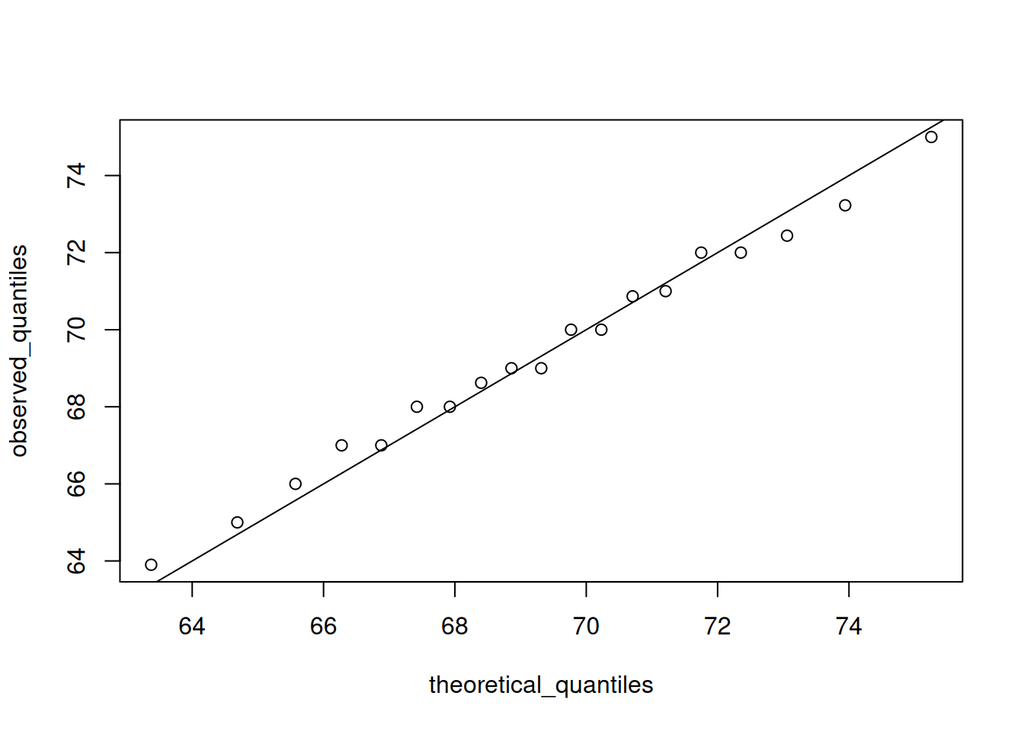

```r
plot(theoretical_quantiles, observed_quantiles)
abline(0,1)
```

Make QQ-plot with scaled values

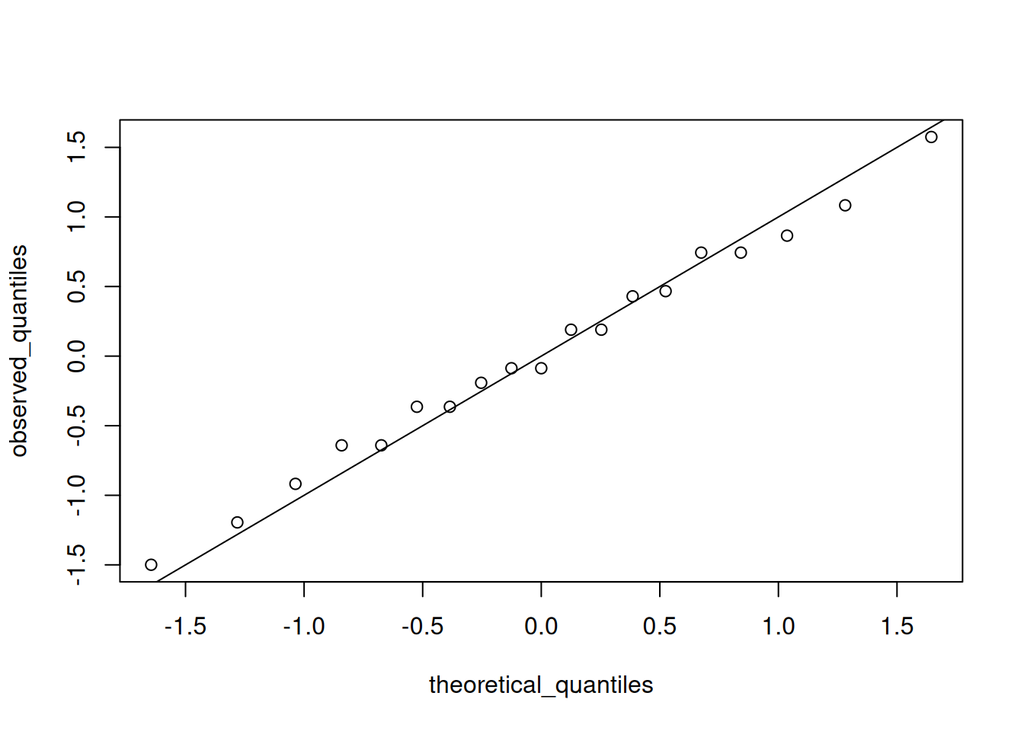

```r
observed_quantiles <- quantile(z, p)
theoretical_quantiles <- qnorm(p)
plot(theoretical_quantiles, observed_quantiles)
abline(0,1)
```

# 9.5 Stratification

In data analysis we often divide observations into groups based on the values of one or more variables associated with those observations. For example in the next section we divide the height values into groups based on a sex variable: females and males. We call this procedure **stratification** and refer to the resulting groups as strata.

Stratification is common in data visualization because we are often interested in how the distribution of variables differs across different subgroups. We will see several examples throughout this part of the book.

# 9.6 Case study: describing student heights (continued)

Using the histogram, density plots, and QQ-plots, we have become convinced that the male height data is well approximated with a normal distribution. In this case, we report back to ET a very succinct summary: male heights follow a normal distribution with an average of 69.3 inches and a SD of 3.6 inches. With this information, ET will have a good idea of what to expect when he meets our male students. However, to provide a complete picture we need to also provide a summary of the female heights.

We learned that boxplots are useful when we want to quickly compare two or more distributions. Here are the heights for men and women:

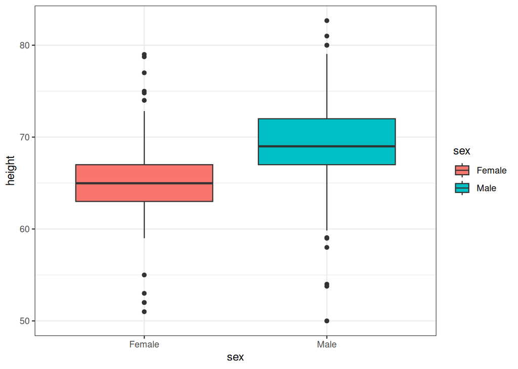

```r
heights |>
  ggplot(aes(x = sex,
             y = height,
             fill = sex)) +
  geom_boxplot()
```

The plot immediately reveals that males are, on average, taller than females. The standard deviations appear to be similar. But does the normal approximation also work for the female height data collected by the survey? We expect that they will follow a normal distribution, just like males. However, exploratory plots reveal that the approximation is not as useful:

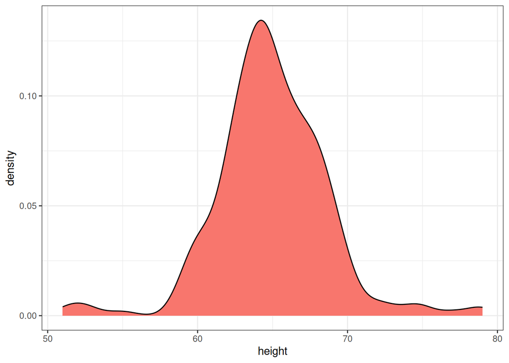

```r
heights |>
  filter(sex == "Female") |>
  ggplot(aes(height)) +
  geom_density(fill = "#F8766D")
```

We see something we did not see for the males: the density plot has a second “bump”. Also, the highest points tend to be taller than expected by the normal than expected heights for a normal distribution. When reporting back to ET, we might need to provide a histogram rather than just the average and standard deviation for the female heights.

However, go back and read Tukey’s quote. We have noticed what we didn’t expect to see. If we look at other female height distributions, we do find that they are well approximated with a normal distribution. So why are our female students different? Is our class a requirement for the female basketball team? Are small proportions of females claiming to be taller than they are? Another, perhaps more likely, explanation is that in the form students used to enter their heights, `FEMALE` was the default sex and some males entered their heights, but forgot to change the sex variable. In any case, data visualization has helped discover a potential flaw in our data.

Regarding the five smallest values, note that these values are:

```r
heights |>
  filter(sex == "Female") |>
  slice_max(desc(height), n=5) |>
  pull(height)
```

```
## [1] 51 52 52 53 55
```

NB. The text uses `top_n` which is deprecated.

Because these are reported heights, a possibility is that the student meant to enter `5'1"`, `5'2"`, `5'3"` or `5'5"`.

# 9.7 Exercises

1. Define variables containing the heights of males and females like this:

```r
library(dslabs)
data(heights)
male <- heights$height[heights$sex == "Male"]
female <- heights$height[heights$sex == "Female"]
```

How many measurements do we have for each?

```r
length(male)
```

```
## [1] 812
```

```r
length(female)
```

```
## [1] 238
```

2. Suppose we can’t make a plot and want to compare the distributions side by side. We can’t just list all the numbers. Instead, we will look at the percentiles. Create a five row table showing female_percentiles and male_percentiles with the 10th, 30th, 50th, 70th, & 90th percentiles for each sex. Then create a data frame with these two as columns.

```r
heights |>
  filter(sex == "Female") |>
  summarise(Females = quantile(height, c(10, 30, 50, 70, 90)/100)) -> fh
heights |>
  filter(sex == "Male") |>
  summarise(Males = quantile(height, c(10, 30, 50, 70, 90)/100)) -> mh
Percentiles <- c("10th","30th","50th","70th","90th")
data.frame(Percentiles, fh, mh)
```

| Percentiles | Females | Males |
| --- | --- | --- |
| 10th | 61.00000 | 65.00000 |
| 30th | 63.00000 | 68.00000 |
| 50th | 64.98031 | 69.00000 |
| 70th | 66.46417 | 71.00000 |
| 90th | 69.00000 | 73.22751 |

3. Study the following boxplots showing population sizes by country:

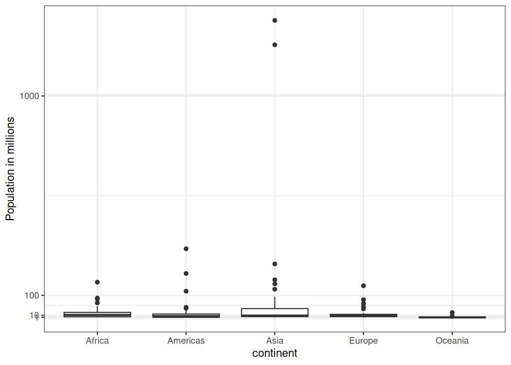

```r
library(tidyverse)
library(dslabs)
ds_theme_set()
data(gapminder)
gapminder |>
  filter(year == 2010) |>
  group_by(continent) |>
  select(continent, population) -> tab
tab |> ggplot(aes(x=continent, y=population/10^6)) +
  geom_boxplot() +
  scale_y_continuous(breaks = c(1,10,100,1000)) +
  ylab("Population in millions")
```

Which continent has the country with the biggest population size? Asia

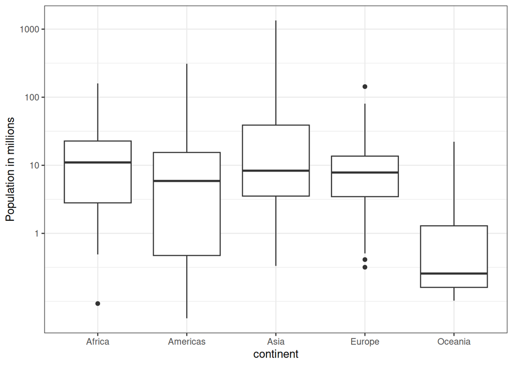

```r
library(tidyverse)
library(dslabs)
ds_theme_set()
data(gapminder)
gapminder |>
  filter(year == 2010) |>
  group_by(continent) |>
  select(continent, population) -> tab
tab |> ggplot(aes(x=continent, y=population/10^6)) +
  geom_boxplot() +
  scale_y_continuous(trans = "log10",
                     breaks = c(1,10,100,1000)) +
  ylab("Population in millions")
```

Americas

8. Load the height data set and create a vector x with just the male heights:

```r
library(dslabs)
data(heights)
x <- heights$height[heights$sex=="Male"]
```

What proportion of the data is between 69 and 72 inches (taller than 69, but shorter or equal to 72)? Hint: use a logical operator and mean.

```r
heights |>
  filter(height < 69 & height <= 72) -> targets
tar_count <- length(targets)
tar_count / mean(heights$height)
```

```
## [1] 0.02927271
```

# 9.8 ggplot2 geometries

## 9.8.1 Barplots

To generate a barplot we can use the **`geom_bar`** geometry. The default is to count the number of each category and draw a bar. Here is the plot for the regions of the US.

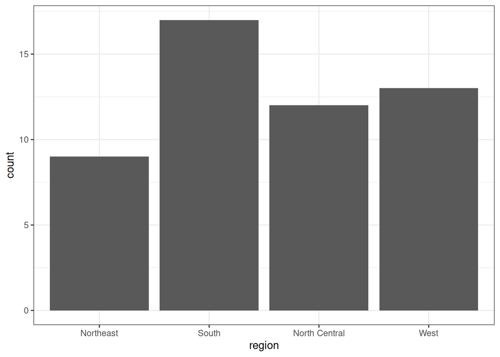

```r
murders |>
  ggplot(aes(region)) +
  geom_bar()
```

We often already have a table with a distribution that we want to present as a barplot. Here is an example of such a table:

```r
data(murders)
murders |>
  count(region) |>
  mutate(proportion = n/sum(n)) -> tab
tab
```

| region | n | proportion |
| --- | --- | --- |
| Northeast | 9 | 0.1764706 |
| South | 17 | 0.3333333 |
| North Central | 12 | 0.2352941 |
| West | 13 | 0.2549020 |

We no longer want `geom_bar` to count, but rather just plot a bar to the height provided by the proportion variable. For this we need to provide `x` (the categories) and `y` (the values) and use the stat=“identity” option.

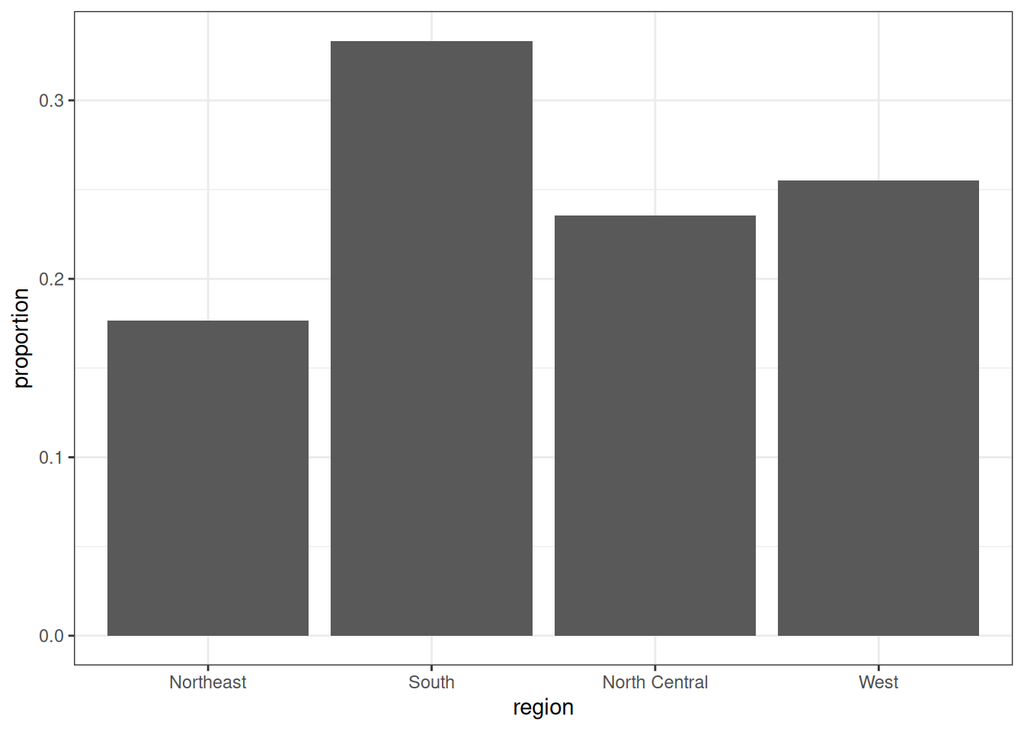

```r
tab |>
  ggplot(aes(region, proportion)) +
  geom_bar(stat = "identity")
```

## 9.8.2 Histograms

To generate histograms we use **`geom_histogram`**. By looking at the help file for this function, we learn that the only required argument is `x`, the variable for which we will construct a histogram. We dropped the `x` because we know it is the first argument. The code looks like this:

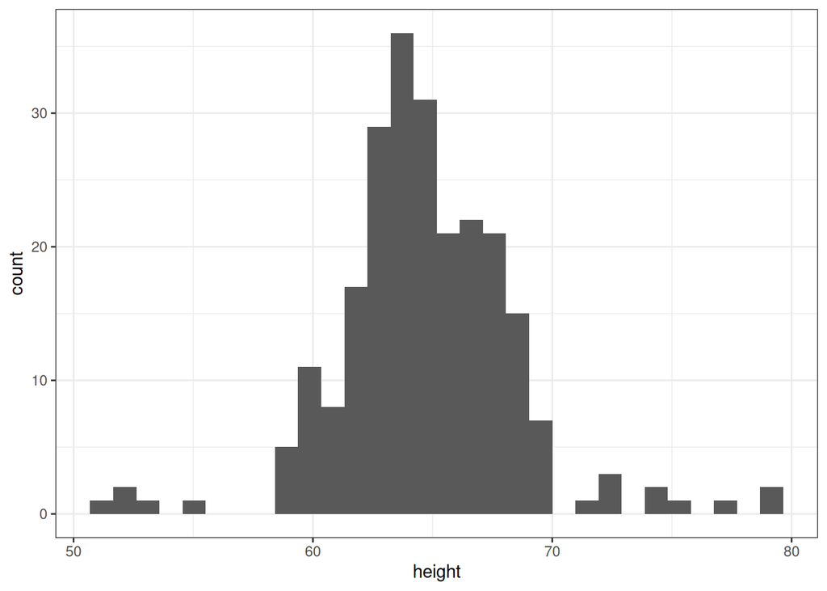

```r
heights |>
  filter(sex == "Female") |>
  ggplot(aes(height)) +
  geom_histogram()
```

We previously used a bin size of 1 inch, so the code looks like this:

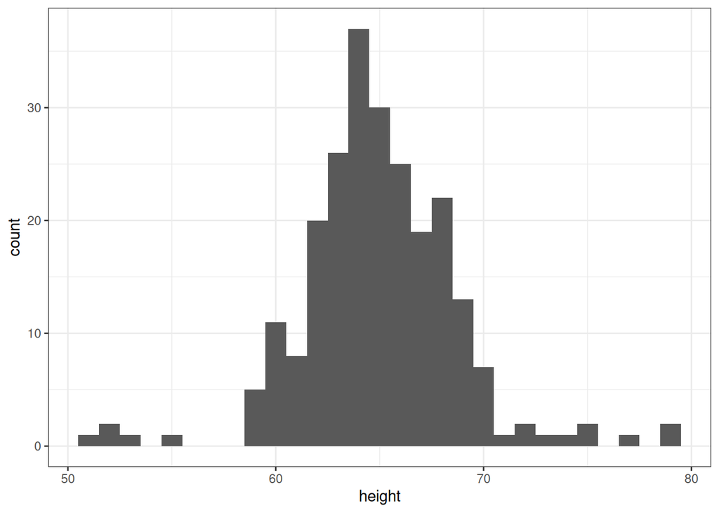

```r
heights |>
  filter(sex == "Female") |>
  ggplot(aes(height)) +
  geom_histogram(binwidth = 1)
```

Finally, if for aesthetic reasons we want to add color, we use the arguments described in the help file. We also add labels and a title:

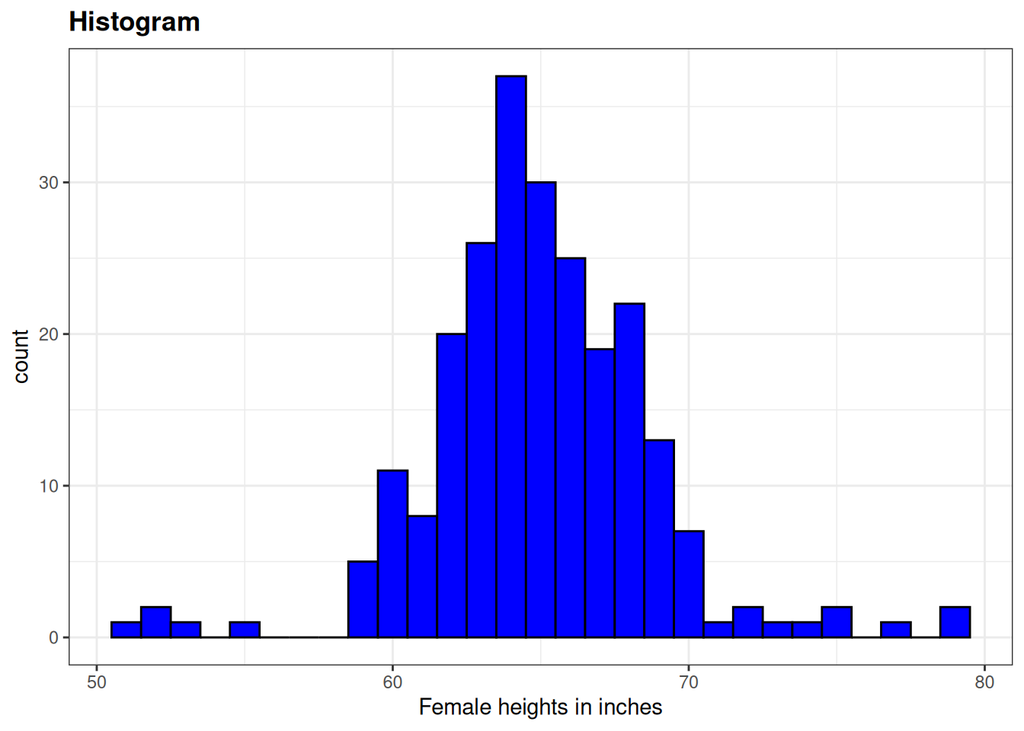

```r
heights |>
  filter(sex == "Female") |>
  ggplot(aes(height)) +
  geom_histogram(binwidth = 1, fill="blue", col="black") +
  xlab("Female heights in inches") +
  ggtitle("Histogram")
```

## 9.8.3 Density plots

To create a smooth density, we use the **`geom_density`**. To make a smooth density plot with the data previously shown as a histogram we can use this code:

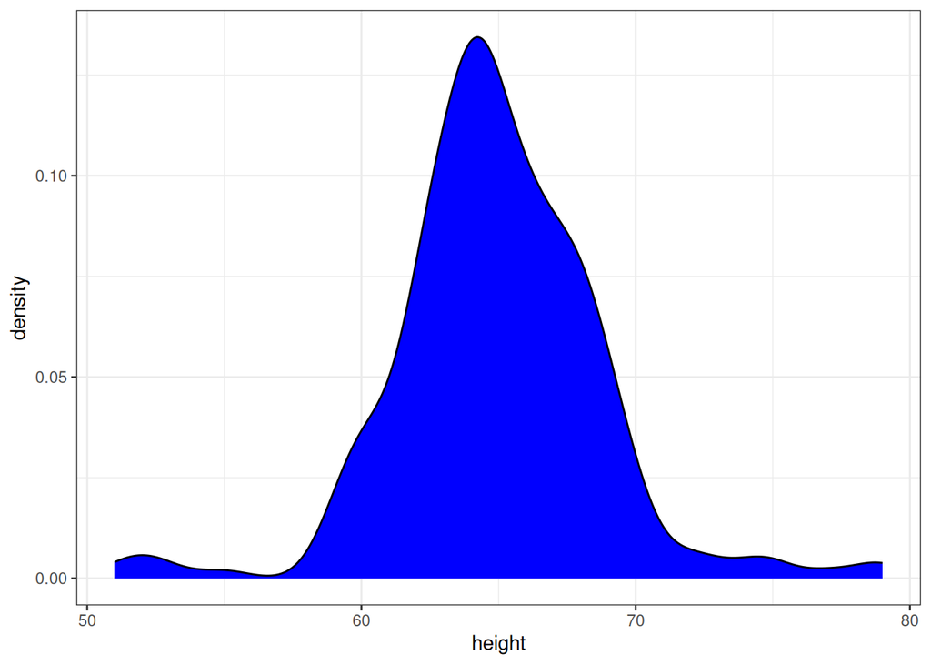

```r
heights |>
  filter(sex == "Female") |>
  ggplot(aes(height)) +
  geom_density(fill = "blue")
```

To change the smoothness of the density, we use the **adjust** argument to multiply the default value by that adjust. For example, if we want the bandwidth to be twice as big we use:

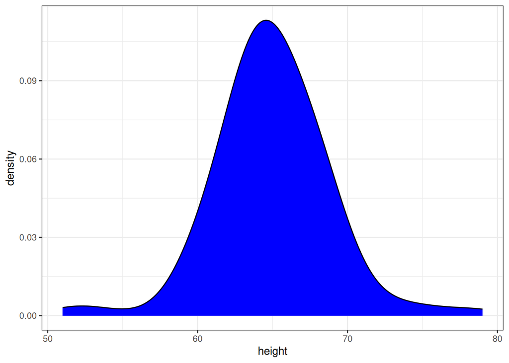

```r
heights |>
  filter(sex == "Female") |>
  ggplot(aes(height)) +
  geom_density(fill = "blue",
               adjust = 2)
```

## 9.8.4 Boxplots

The geometry for boxplot is **`geom_boxplot`**. As discussed, boxplots are useful for comparing distributions. For example, below are the previously shown heights for women, but compared to men. For this geometry, we need arguments x as the categories, and y as the values.

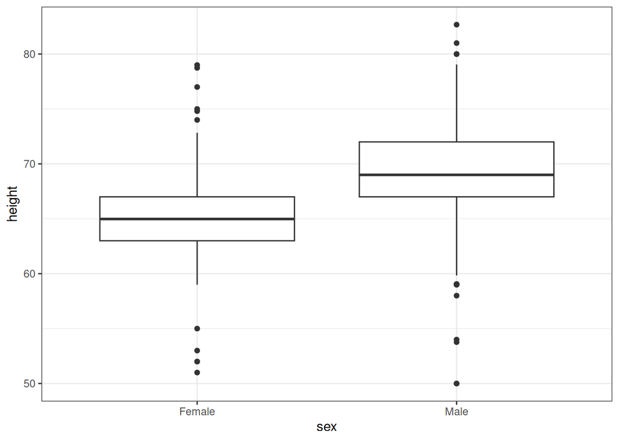

```r
heights |>
  ggplot(aes(sex,height)) +
  geom_boxplot()
```

## QQ-plots

For qq-plots we use the **`geom_qq`** geometry. From the help file, we learn that we need to specify the `sample` (we will learn about samples in a later chapter). Here is the `qqplot` for men heights.

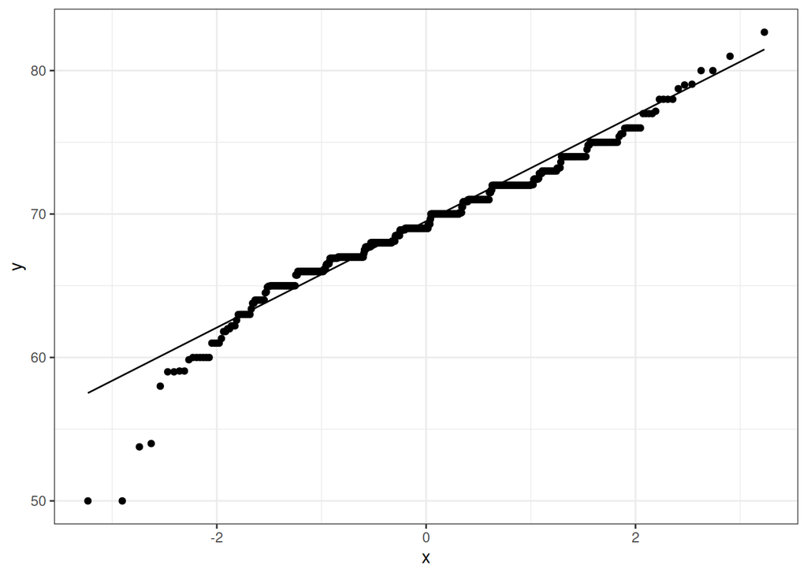

```r
heights |>
  filter(sex == "Male") |>
  ggplot(aes(sample = height)) +
  geom_qq() +
  geom_qq_line()
```

By default, the sample variable is compared to a normal distribution with average 0 and standard deviation 1. To change this, we use the `dparams` arguments based on the help file. Adding an identity line is as simple as assigning another layer. For straight lines, we use the `geom_abline` function. The default line is the identity line (slope = 1, intercept = 0).

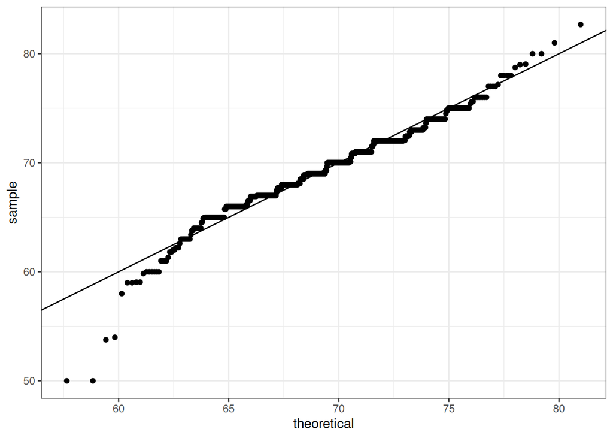

```r
params <-
  heights |>
  filter(sex == "Male") |>
  summarise(mean = mean(height),
            sd = sd(height))
heights |>
  filter(sex == "Male") |>
  ggplot(aes(sample = height)) +
  geom_qq(dparams = params) +
  geom_abline()
```

Another option here is to scale the data first and then make a qqplot against the standard normal.

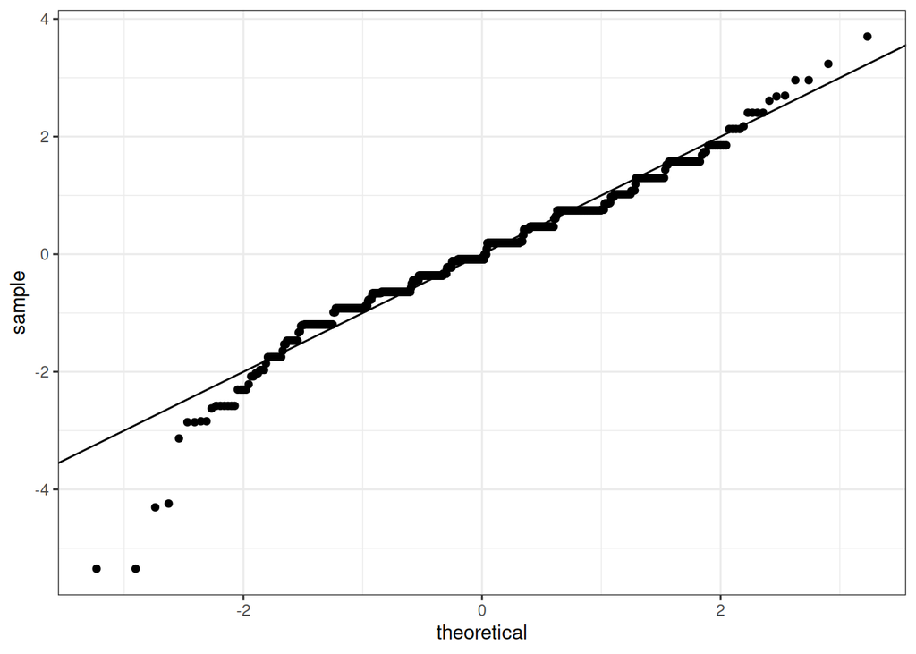

```r
heights |>
  filter(sex == "Male") |>
  ggplot(aes(sample = scale(height))) +
  geom_qq() +
  geom_abline()
```

## 9.8.5 Images

Images were not needed for the concepts described in this chapter, but we will use images in Section 11.14, so we introduce the two geometries used to create images: **`geom_tile`** and **`geom_raster`**. They behave similarly; to see how they differ, please consult the help file. To create an image in **ggplot2** we need a data frame with the x and y coordinates as well as the values associated with each of these. Here is a data frame.

```r
x <- expand.grid(x = 1:12, y = 1:10) |>
  mutate(z = 1:120)
x
```

| x | y | z |
| --- | --- | --- |
| 1 | 1 | 1 |
| 2 | 1 | 2 |
| 3 | 1 | 3 |
| 4 | 1 | 4 |
| 5 | 1 | 5 |
| 6 | 1 | 6 |
| 7 | 1 | 7 |
| 8 | 1 | 8 |
| 9 | 1 | 9 |
| 10 | 1 | 10 |

[output cut: 110 more lines]

Note that this is the tidy version of a matrix, matrix(1:120, 12, 10). To plot the image we use the following code:

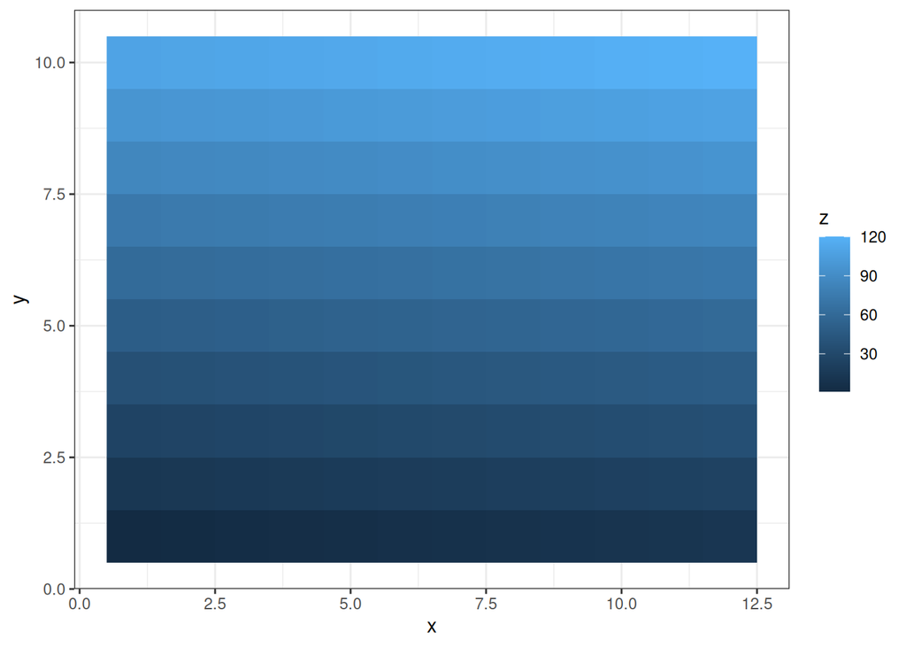

```r
x |>
  ggplot(aes(x, y, fill = z)) +
  geom_raster()
```

With these images you will often want to change the color scale. This can be done through the **`scale_fill_gradient`** layer.

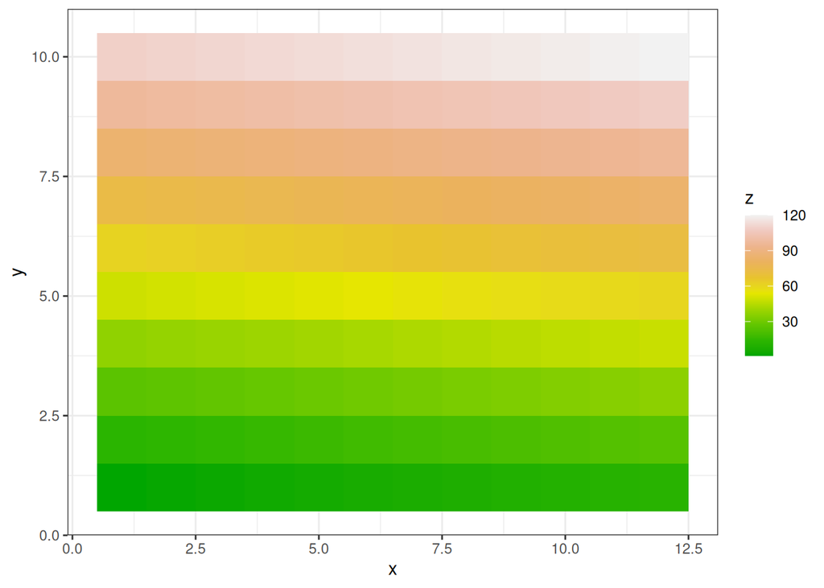

```r
x |>
  ggplot(aes(x, y, fill = z)) +
  geom_raster() +
  scale_fill_gradientn(colors =  terrain.colors(10))
```

```r
x
```

| x | y | z |
| --- | --- | --- |
| 1 | 1 | 1 |
| 2 | 1 | 2 |
| 3 | 1 | 3 |
| 4 | 1 | 4 |
| 5 | 1 | 5 |
| 6 | 1 | 6 |
| 7 | 1 | 7 |
| 8 | 1 | 8 |
| 9 | 1 | 9 |
| 10 | 1 | 10 |

[output cut: 110 more lines]

NB from the docs

> `geom_rect` and `geom_til`e do the same thing, but are parameterised differently: `geom_rect` uses the locations of the four corners (`xmin`, `xmax`, `ymin` and `ymax`), while `geom_tile` uses the center of the tile and its size (`x`, `y`, `width`, `height`). `geom_raster` is a high performance special case for when all the tiles are the same size.